# **Brewing Insights: A Study of Indian Café Culture**

**- BY DIVIT SRIVASTAVA**

**IMPORTING DATA**

```python
from google.colab import drive
drive.mount('/content/drive')
```

```python
import pandas as pd
from google.colab import drive
drive.mount('/content/drive')
```

```python
df = pd.read_csv('//content/drive/MyDrive/Colab Notebooks/Zomato Big Data Analysis/zomato.csv', encoding='latin-1')
```

# **GLOBAL RESTAURANT DATA**

```python
df
```

|  | Restaurant ID | Restaurant Name | Country Code | City | Address | Locality | Locality Verbose | Longitude | Latitude | Cuisines | ... | Currency | Has Table booking | Has Online delivery | Is delivering now | Switch to order menu | Price range | Aggregate rating | Rating color | Rating text | Votes |
| --- | --- | --- | --- | --- | --- | --- | --- | --- | --- | --- | --- | --- | --- | --- | --- | --- | --- | --- | --- | --- | --- |
| 0 | 6317637 | Le Petit Souffle | 162 | Makati City | Third Floor, Century City Mall, Kalayaan Avenu... | Century City Mall, Poblacion, Makati City | Century City Mall, Poblacion, Makati City, Mak... | 121.027535 | 14.565443 | French, Japanese, Desserts | ... | Botswana Pula(P) | Yes | No | No | No | 3 | 4.8 | Dark Green | Excellent | 314 |
| 1 | 6304287 | Izakaya Kikufuji | 162 | Makati City | Little Tokyo, 2277 Chino Roces Avenue, Legaspi... | Little Tokyo, Legaspi Village, Makati City | Little Tokyo, Legaspi Village, Makati City, Ma... | 121.014101 | 14.553708 | Japanese | ... | Botswana Pula(P) | Yes | No | No | No | 3 | 4.5 | Dark Green | Excellent | 591 |
| 2 | 6300002 | Heat - Edsa Shangri-La | 162 | Mandaluyong City | Edsa Shangri-La, 1 Garden Way, Ortigas, Mandal... | Edsa Shangri-La, Ortigas, Mandaluyong City | Edsa Shangri-La, Ortigas, Mandaluyong City, Ma... | 121.056831 | 14.581404 | Seafood, Asian, Filipino, Indian | ... | Botswana Pula(P) | Yes | No | No | No | 4 | 4.4 | Green | Very Good | 270 |
| 3 | 6318506 | Ooma | 162 | Mandaluyong City | Third Floor, Mega Fashion Hall, SM Megamall, O... | SM Megamall, Ortigas, Mandaluyong City | SM Megamall, Ortigas, Mandaluyong City, Mandal... | 121.056475 | 14.585318 | Japanese, Sushi | ... | Botswana Pula(P) | No | No | No | No | 4 | 4.9 | Dark Green | Excellent | 365 |
| 4 | 6314302 | Sambo Kojin | 162 | Mandaluyong City | Third Floor, Mega Atrium, SM Megamall, Ortigas... | SM Megamall, Ortigas, Mandaluyong City | SM Megamall, Ortigas, Mandaluyong City, Mandal... | 121.057508 | 14.584450 | Japanese, Korean | ... | Botswana Pula(P) | Yes | No | No | No | 4 | 4.8 | Dark Green | Excellent | 229 |
| ... | ... | ... | ... | ... | ... | ... | ... | ... | ... | ... | ... | ... | ... | ... | ... | ... | ... | ... | ... | ... | ... |
| 9546 | 5915730 | NamlÛ± Gurme | 208 | ÛÁstanbul | Kemankeô Karamustafa Paôa Mahallesi, RÛ±htÛ±... | Karakí_y | Karakí_y, ÛÁstanbul | 28.977392 | 41.022793 | Turkish | ... | Turkish Lira(TL) | No | No | No | No | 3 | 4.1 | Green | Very Good | 788 |
| 9547 | 5908749 | Ceviz AÛôacÛ± | 208 | ÛÁstanbul | Koôuyolu Mahallesi, Muhittin íìstí_ndaÛô Cadd... | Koôuyolu | Koôuyolu, ÛÁstanbul | 29.041297 | 41.009847 | World Cuisine, Patisserie, Cafe | ... | Turkish Lira(TL) | No | No | No | No | 3 | 4.2 | Green | Very Good | 1034 |
| 9548 | 5915807 | Huqqa | 208 | ÛÁstanbul | Kuruí_eôme Mahallesi, Muallim Naci Caddesi, N... | Kuruí_eôme | Kuruí_eôme, ÛÁstanbul | 29.034640 | 41.055817 | Italian, World Cuisine | ... | Turkish Lira(TL) | No | No | No | No | 4 | 3.7 | Yellow | Good | 661 |
| 9549 | 5916112 | Aôôk Kahve | 208 | ÛÁstanbul | Kuruí_eôme Mahallesi, Muallim Naci Caddesi, N... | Kuruí_eôme | Kuruí_eôme, ÛÁstanbul | 29.036019 | 41.057979 | Restaurant Cafe | ... | Turkish Lira(TL) | No | No | No | No | 4 | 4.0 | Green | Very Good | 901 |
| 9550 | 5927402 | Walter's Coffee Roastery | 208 | ÛÁstanbul | CafeaÛôa Mahallesi, BademaltÛ± Sokak, No 21/B,... | Moda | Moda, ÛÁstanbul | 29.026016 | 40.984776 | Cafe | ... | Turkish Lira(TL) | No | No | No | No | 2 | 4.0 | Green | Very Good | 591 |

9551 rows × 21 columns

# **FILTERING INDIAN RESTAURANTS**

Refining the data frame to filter Indian Restaurants only

```python
Indiadf=df[df['Country Code']==1]
Indiadf. to_csv('//content/drive/MyDrive/Colab Notebooks/Zomato Big Data Analysis/Only-India.csv', index=False)
removingcolumns = ['Latitude', 'Longitude', 'Switch to order menu']
Indiadf = Indiadf.drop(removingcolumns, axis=1)
Indiadf
```

|  | Restaurant ID | Restaurant Name | Country Code | City | Address | Locality | Locality Verbose | Cuisines | Average Cost for two | Currency | Has Table booking | Has Online delivery | Is delivering now | Price range | Aggregate rating | Rating color | Rating text | Votes |
| --- | --- | --- | --- | --- | --- | --- | --- | --- | --- | --- | --- | --- | --- | --- | --- | --- | --- | --- |
| 624 | 3400025 | Jahanpanah | 1 | Agra | E 23, Shopping Arcade, Sadar Bazaar, Agra Cant... | Agra Cantt | Agra Cantt, Agra | North Indian, Mughlai | 850 | Indian Rupees(Rs.) | No | No | No | 3 | 3.9 | Yellow | Good | 140 |
| 625 | 3400341 | Rangrezz Restaurant | 1 | Agra | E-20, Shopping Arcade, Sadar Bazaar, Agra Cant... | Agra Cantt | Agra Cantt, Agra | North Indian, Mughlai | 700 | Indian Rupees(Rs.) | No | No | No | 2 | 3.5 | Yellow | Good | 71 |
| 626 | 3400005 | Time2Eat - Mama Chicken | 1 | Agra | Main Market, Sadar Bazaar, Agra Cantt, Agra | Agra Cantt | Agra Cantt, Agra | North Indian | 500 | Indian Rupees(Rs.) | No | No | No | 2 | 3.6 | Yellow | Good | 94 |
| 627 | 3400021 | Chokho Jeeman Marwari Jain Bhojanalya | 1 | Agra | 1/48, Delhi Gate, Station Road, Raja Mandi, Ci... | Civil Lines | Civil Lines, Agra | Rajasthani | 400 | Indian Rupees(Rs.) | No | No | No | 2 | 4.0 | Green | Very Good | 87 |
| 628 | 3400017 | Pinch Of Spice | 1 | Agra | 23/453, Opposite Sanjay Cinema, Wazipura Road,... | Civil Lines | Civil Lines, Agra | North Indian, Chinese, Mughlai | 1000 | Indian Rupees(Rs.) | No | No | No | 3 | 4.2 | Green | Very Good | 177 |
| ... | ... | ... | ... | ... | ... | ... | ... | ... | ... | ... | ... | ... | ... | ... | ... | ... | ... | ... |
| 9271 | 2800100 | D Cabana | 1 | Vizag | Beach Road, Near Bus Stop, Sagar Nagar, Visakh... | Sagar Nagar | Sagar Nagar, Vizag | Continental, Seafood, Chinese, North Indian, B... | 600 | Indian Rupees(Rs.) | No | No | No | 2 | 3.6 | Yellow | Good | 193 |
| 9272 | 2800418 | Kaloreez | 1 | Vizag | Plot 95, Opposite St. Lukes Nursing School, Da... | Siripuram | Siripuram, Vizag | Cafe, North Indian, Chinese | 400 | Indian Rupees(Rs.) | No | No | No | 2 | 3.7 | Yellow | Good | 85 |
| 9273 | 2800881 | Plot 17 | 1 | Vizag | Plot 17, Gangapur Layout, Siripuram, Vizag | Siripuram | Siripuram, Vizag | Burger, Pizza, Biryani | 600 | Indian Rupees(Rs.) | No | No | No | 2 | 4.3 | Green | Very Good | 172 |
| 9274 | 2800042 | Vista - The Park | 1 | Vizag | The Park, Beach Road, Pedda Waltair, Lawsons B... | The Park, Lawsons Bay | The Park, Lawsons Bay, Vizag | American, North Indian, Thai, Continental | 1500 | Indian Rupees(Rs.) | No | No | No | 4 | 3.8 | Yellow | Good | 74 |
| 9275 | 2800019 | Flying Spaghetti Monster | 1 | Vizag | 10-50-12/F2, Sai Dakshata Complex, Beside Leno... | Waltair Uplands | Waltair Uplands, Vizag | Italian | 1400 | Indian Rupees(Rs.) | No | No | No | 3 | 4.4 | Green | Very Good | 316 |

8652 rows × 18 columns

# **FILTERING CAFES**

Refining the data frame further to filter the cafes

```python
def hascafe(x):
  if 'Cafe' in x:
    return 'Yes'
  else:
    return 'No'

cafe=Indiadf.copy()
cafe=cafe[cafe['Cuisines'].apply(hascafe)=='Yes']
```

# **STUDYING THE CAFE DATA**

```python
cafe
```

|  | Restaurant ID | Restaurant Name | Country Code | City | Address | Locality | Locality Verbose | Cuisines | Average Cost for two | Currency | Has Table booking | Has Online delivery | Is delivering now | Price range | Aggregate rating | Rating color | Rating text | Votes |
| --- | --- | --- | --- | --- | --- | --- | --- | --- | --- | --- | --- | --- | --- | --- | --- | --- | --- | --- |
| 637 | 3400346 | Sheroes Hangout | 1 | Agra | Opposite The Gateway Hotel, Fatehabad Road, Ta... | Tajganj | Tajganj, Agra | Cafe, North Indian, Chinese | 0 | Indian Rupees(Rs.) | No | No | No | 1 | 4.9 | Dark Green | Excellent | 77 |
| 639 | 3400391 | Chapter 1 Cafe | 1 | Agra | 1374 K/1375 K, 2nd floor, Dinesh Nagar, Fatehb... | Tajganj | Tajganj, Agra | Cafe, Italian, Mexican, North Indian, Continental | 0 | Indian Rupees(Rs.) | No | No | No | 1 | 3.9 | Yellow | Good | 98 |
| 650 | 18143128 | Mocha | 1 | Ahmedabad | 6-9, Ground Floor, Devashish Business Park, Op... | Bodakdev | Bodakdev, Ahmedabad | Cafe, Continental, Desserts | 1000 | Indian Rupees(Rs.) | No | Yes | No | 3 | 4.4 | Green | Very Good | 944 |
| 651 | 18438944 | Blue - Rooftop Cafe Restaurant Bistro | 1 | Ahmedabad | 10th Floor, Balaji Heights Buliding, Behind Ta... | C G Road | C G Road, Ahmedabad | North Indian, Cafe, Italian, Mexican, Continental | 1000 | Indian Rupees(Rs.) | No | Yes | No | 3 | 3.8 | Yellow | Good | 63 |
| 658 | 113703 | Cafe Alfresco | 1 | Ahmedabad | 101, Dynamic House, Vijay Cross Road, Above HD... | Navrangpura | Navrangpura, Ahmedabad | Cafe, Beverages, Desserts, Pizza | 700 | Indian Rupees(Rs.) | No | Yes | No | 2 | 4.0 | Green | Very Good | 404 |
| ... | ... | ... | ... | ... | ... | ... | ... | ... | ... | ... | ... | ... | ... | ... | ... | ... | ... | ... |
| 9250 | 3900009 | eastWEST - Radisson Hotel | 1 | Varanasi | Radisson Hotel, The Mall Road, Nadesar, Varanasi | Radisson Hotel, Nadesar | Radisson Hotel, Nadesar, Varanasi | Cafe, North Indian, Continental | 600 | Indian Rupees(Rs.) | No | No | No | 3 | 3.3 | Orange | Average | 34 |
| 9253 | 18346996 | 3Cherryz Sky Lounge & Cafe | 1 | Varanasi | 5th Floor Roof Top,(Above Big Bazaar) Sigra. O... | Sigra | Sigra, Varanasi | Cafe, North Indian, Chinese | 500 | Indian Rupees(Rs.) | No | No | No | 3 | 3.2 | Orange | Average | 26 |
| 9263 | 2800911 | Double Roti | 1 | Vizag | Ground Floor, ATR Towers, Harbour Park Road, P... | Kirlampudi Layout | Kirlampudi Layout, Vizag | Cafe, Fast Food, American | 1000 | Indian Rupees(Rs.) | No | No | No | 3 | 3.8 | Yellow | Good | 27 |
| 9267 | 18306045 | Percolator Coffee House | 1 | Vizag | RK Beach, Maharani Peta, Vizag Visakhapatnam.,... | Maharani Peta | Maharani Peta, Vizag | Mughlai, Chinese, Cafe, BBQ, Cajun | 500 | Indian Rupees(Rs.) | No | No | No | 2 | 3.6 | Yellow | Good | 84 |
| 9272 | 2800418 | Kaloreez | 1 | Vizag | Plot 95, Opposite St. Lukes Nursing School, Da... | Siripuram | Siripuram, Vizag | Cafe, North Indian, Chinese | 400 | Indian Rupees(Rs.) | No | No | No | 2 | 3.7 | Yellow | Good | 85 |

627 rows × 18 columns

```python
import matplotlib.pyplot as plt
import seaborn as sns
import numpy as np
```

**FINDING THE CITIES WITH THE MOST NUMBER OF CAFES**

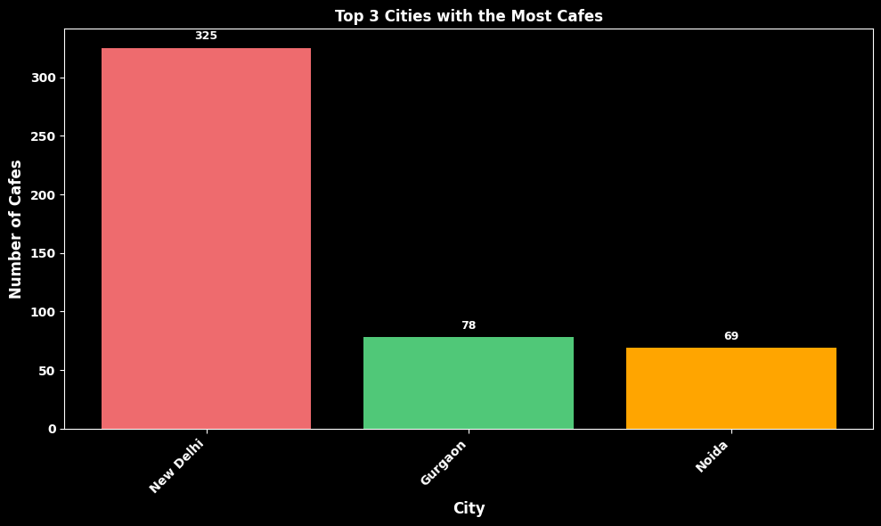

```python
import matplotlib.pyplot as plt
top_3_cafe_cities = cafe.groupby('City')['Restaurant Name'].count().sort_values(ascending=False).head(3)

plt.figure(figsize=(10, 6))
plt.style.use('dark_background')
plt.bar(top_3_cafe_cities.index, top_3_cafe_cities.values, color=['#ee6b6e', '#50C878','#FFA500'])
plt.xlabel('City', fontsize=12, fontfamily='sans-serif',fontweight='bold')
plt.ylabel('Number of Cafes', fontsize=12, fontfamily='sans-serif',fontweight='bold')
plt.title('Top 3 Cities with the Most Cafes', fontsize=12, fontfamily='sans-serif',fontweight='bold')

plt.xticks(rotation=45, ha='right', fontsize=10, fontweight='bold')
plt.yticks(ha='right', fontsize=10, fontweight='bold')

for i, v in enumerate(top_3_cafe_cities.values):
    plt.text(i, v + 5, str(v), ha='center', va='bottom', fontsize=9, color='white',fontweight='bold')

plt.tight_layout()
plt.show()
```

**TOP 3 CITIES WITH THE MOST NUMBER OF CAFES**

1. **New Delhi - 325**
2. Gurgaon - 78
3. Noida - 69

**CAFES WHO DO HOME DELIVERY**

```python
print(cafe['Has Online delivery'].value_counts())
```

```
Has Online delivery
No     440
Yes    187
Name: count, dtype: int64
```

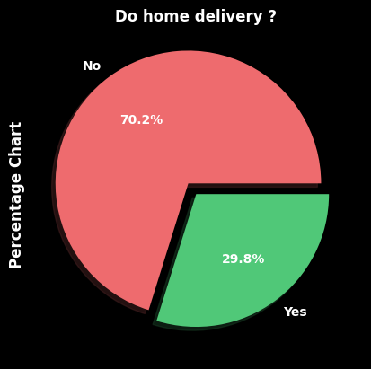

```python
import matplotlib.pyplot as plt
import matplotlib.font_manager as fm

plt.style.use('dark_background')

wedges, texts, autotexts = plt.pie(
    cafe['Has Online delivery'].value_counts(),
    autopct='%1.1f%%',
    shadow=True,
    explode=(0.1, 0),
    colors=['#ee6b6e', '#50C878'],
    labels=['No', 'Yes'],
    textprops={'weight': 'bold'}
)

plt.title('Do home delivery ?', fontweight='bold',fontsize=12, fontfamily='sans-serif')
plt.setp(autotexts, weight='bold',fontsize=10,fontfamily='sans-serif')
plt.ylabel('Percentage Chart',fontsize=12, fontfamily='sans-serif',fontweight='bold')

plt.show()
```

**Has Online delivery ?**

**No : 440**

**Yes : 187**

**HOW PRICING AFFECTS POPULARITY**

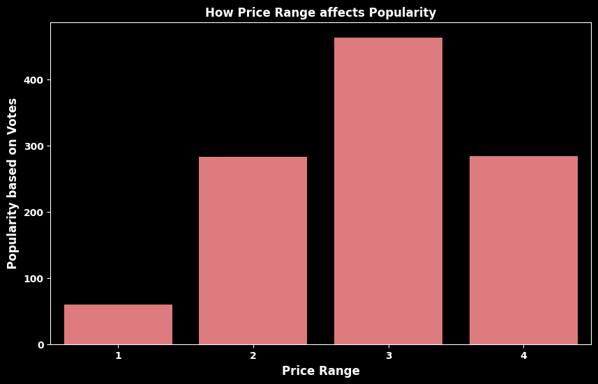

```python
cafe['Votes'] = pd.to_numeric(Indiadf['Votes'], errors='coerce')
price_range_votes = cafe.groupby('Price range')['Votes'].mean()
plt.figure(figsize=(10, 6))
plt.style.use('dark_background')
sns.barplot(x=price_range_votes.index, y=price_range_votes.values,color='#ee6b6e')
plt.title('How Price Range affects Popularity',fontsize=12, fontfamily='sans-serif',fontweight='bold')
plt.xlabel('Price Range',fontsize=12, fontfamily='sans-serif',fontweight='bold')
plt.ylabel('Popularity based on Votes',fontsize=12, fontfamily='sans-serif',fontweight='bold')
plt.xticks(fontsize=10, fontweight='bold')
plt.yticks(ha='right', fontsize=10, fontweight='bold')
plt.show()
```

**ANALYZING CAFE RATINGS**

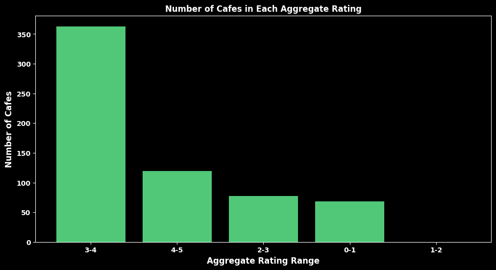

```python
bins = [0, 1, 2, 3, 4, 5 ]
labels = ['0-1', '1-2', '2-3', '3-4', '4-5']
cafe['rating'] = pd.cut(cafe['Aggregate rating'], bins=bins, labels=labels, include_lowest=True)


rating_counts = cafe['rating'].value_counts()


plt.figure(figsize=(12, 6))
plt.style.use('dark_background')
plt.bar(rating_counts.index, rating_counts.values, color='#50C878')
plt.xlabel('Aggregate Rating Range',fontsize=12, fontfamily='sans-serif',fontweight='bold')
plt.ylabel('Number of Cafes',fontsize=12, fontfamily='sans-serif',fontweight='bold')
plt.title('Number of Cafes in Each Aggregate Rating',fontsize=12, fontfamily='sans-serif',fontweight='bold')
plt.xticks(fontsize=10, fontweight='bold')
plt.yticks(ha='right', fontsize=10, fontweight='bold')
plt.show()
```

**THE MAJORITY OF CAFES RECEIVE A RATING BETWEEN 3 AND 5**

**ANALYZING HOW POPULARITY AFFECTS RATING**

```python
cafe_filtered = cafe[cafe['Aggregate rating'] >= 3.5]
```

```python
cafe_filtered = cafe_filtered[cafe_filtered['Votes'] >= 3000]
```

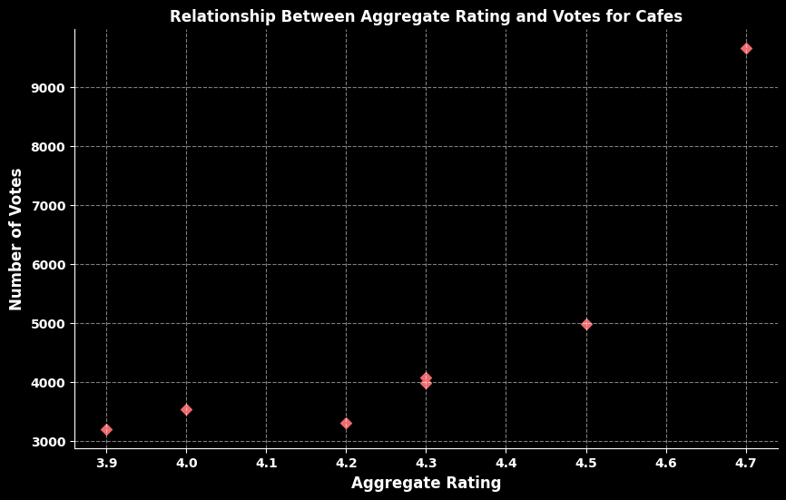

```python
import matplotlib.pyplot as plt
plt.figure(figsize=(10, 6))
plt.style.use('dark_background')
plt.scatter(cafe_filtered['Aggregate rating'], cafe_filtered['Votes'], marker='D', color='#ee6b6e')
plt.xlabel('Aggregate Rating')
plt.ylabel('Votes')
plt.gca().spines[['top', 'right',]].set_visible(False)
plt.gca().spines[['top', 'right',]].set_visible(False)
plt.grid(True, linestyle='--', alpha=0.5)
plt.title('Relationship Between Aggregate Rating and Votes for Cafes',fontsize=12, fontfamily='sans-serif',fontweight='bold')
plt.xlabel('Aggregate Rating',fontsize=12, fontfamily='sans-serif',fontweight='bold')
plt.ylabel('Number of Votes',fontsize=12, fontfamily='sans-serif',fontweight='bold')
plt.xticks(fontsize=10, fontweight='bold')
plt.yticks(ha='right', fontsize=10, fontweight='bold')
plt.show()
```

**HIGHER RATED RESTAURANTS ARE EXCEPTIONALLY POPULAR**

**WHAT PERCENTAGE OF CAFES ARE PURELY CAFES**

```python
def only_cafe(x):
  if x == 'Cafe':
    return 'Yes'
  else:
    return 'No'

pure_cafe = cafe.copy()
pure_cafe = pure_cafe[pure_cafe['Cuisines'].apply(only_cafe)=='Yes']
```

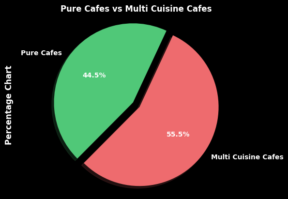

```python
pure_cafe_percentage = (len(pure_cafe) / len(cafe)) * 100
other_cafe_percentage = 100 - pure_cafe_percentage

labels = ['Pure Cafes', 'Multi Cuisine Cafes']
sizes = [pure_cafe_percentage, other_cafe_percentage]
colors = ['#50C878', '#ee6b6e']
wedges, texts, autotexts = plt.pie(sizes,
                                  labels=labels,
                                  colors=colors,
                                  autopct='%1.1f%%',
                                  shadow=True,
                                  explode=(0.1, 0),
                                  startangle=65,
                                  textprops={'weight': 'bold'})


plt.setp(autotexts, weight='bold', fontsize=10, fontfamily='sans-serif')
plt.axis('equal')
plt.style.use('dark_background')
plt.title('Pure Cafes vs Multi Cuisine Cafes', fontsize=12, fontfamily='sans-serif', fontweight='bold')
plt.ylabel('Percentage Chart', fontsize=12, fontfamily='sans-serif', fontweight='bold')
plt.show()
```

**Pure Cafes - 44.5%**

**Multi Cuisine Cafes - 55.5%**

**PERFORMANCE OF PURE CAFES VS MULTI-CUISINE CAFES**

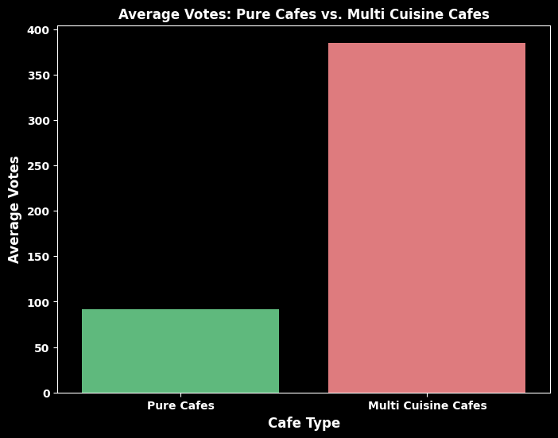

```python
import matplotlib.pyplot as plt
import seaborn as sns


pure_cafe_avg_votes = pure_cafe['Votes'].mean()
other_cafe = cafe[cafe['Cuisines'].apply(only_cafe)=='No']
other_cafe_avg_votes = other_cafe['Votes'].mean()

plt.figure(figsize=(8, 6))
plt.style.use('dark_background')
sns.barplot(x=['Pure Cafes', 'Multi Cuisine Cafes'],
            y=[pure_cafe_avg_votes, other_cafe_avg_votes],
            hue=['Pure Cafes', 'Multi Cuisine Cafes'],
            palette=['#50C878', '#ee6b6e'],
            dodge=False, legend=False)
plt.title('Average Votes: Pure Cafes vs. Multi Cuisine Cafes',fontsize=12, fontfamily='sans-serif',fontweight='bold')
plt.ylabel('Average Votes',fontsize=12, fontfamily='sans-serif',fontweight='bold')
plt.xlabel('Cafe Type',fontsize=12, fontfamily='sans-serif',fontweight='bold')
plt.xticks(fontsize=10, fontweight='bold')
plt.yticks(fontsize=10, fontweight='bold')
plt.show()
```

**POPULARITY OF MULTI CUISINE CAFES IS A LOT HIGHER THAN PURE CAFES**

**FINDING HOW MUCH PEOPLE SPEND ON CAFES**

```python
cafe
cafe.drop(['Rating color'],axis=1,inplace=True)
```

```python
columns=['Restaurant Name','Average Cost for two']
filteringforaveragecost = cafe.query('`Average Cost for two` != 0')
df=filteringforaveragecost[columns]
```

**AVERAGE SPEND ON A CAFE FOR TWO PEOPLE**

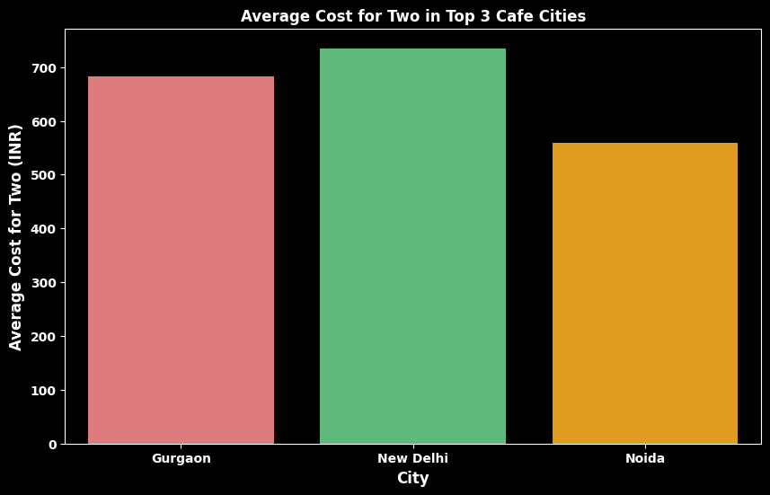

```python
import matplotlib.pyplot as plt
import seaborn as sns

top_3_cities = ['New Delhi', 'Gurgaon', 'Noida']
cafe_top_3 = cafe[cafe['City'].isin(top_3_cities)]
avg_cost_by_city = cafe_top_3.groupby('City')['Average Cost for two'].mean()

plt.figure(figsize=(10, 6))
plt.style.use('dark_background')
sns.barplot(x=avg_cost_by_city.index, y=avg_cost_by_city.values, hue=avg_cost_by_city.index, palette=['#ee6b6e', '#50C878','#FFA500'], dodge=False, legend=False)
plt.title('Average Cost for Two in Top 3 Cafe Cities', fontsize=12, fontfamily='sans-serif',fontweight='bold')
plt.xlabel('City', fontsize=12, fontfamily='sans-serif',fontweight='bold')
plt.ylabel('Average Cost for Two (INR)', fontsize=12, fontfamily='sans-serif',fontweight='bold')
plt.xticks(fontsize=10, fontweight='bold')
plt.yticks(ha='right', fontsize=10, fontweight='bold')
plt.show()
```

```python
df=filteringforaveragecost['Average Cost for two']
a=df.mean()
print("Average spend on cafes is INR ",a)
```

```
Average spend on cafes is INR  694.9519230769231
```

**Average spend on cafes for two people is INR 694**

**MAXIMUM SPEND ON A CAFE FOR TWO PEOPLE**

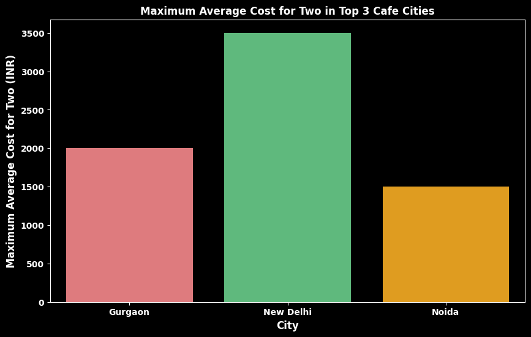

```python
import matplotlib.pyplot as plt
import seaborn as sns

top_3_cities = ['New Delhi', 'Gurgaon', 'Noida']
cafe_top_3 = cafe[cafe['City'].isin(top_3_cities)]
max_cost_by_city = cafe_top_3.groupby('City')['Average Cost for two'].max()

plt.figure(figsize=(10, 6))
plt.style.use('dark_background')
sns.barplot(x=max_cost_by_city.index, y=max_cost_by_city.values, hue=max_cost_by_city.index, palette=['#ee6b6e', '#50C878','#FFA500'], dodge=False, legend=False)
plt.title('Maximum Average Cost for Two in Top 3 Cafe Cities', fontsize=12, fontfamily='sans-serif',fontweight='bold')
plt.xlabel('City', fontsize=12, fontfamily='sans-serif',fontweight='bold')
plt.ylabel('Maximum Average Cost for Two (INR)', fontsize=12, fontfamily='sans-serif',fontweight='bold')
plt.xticks(fontsize=10, fontweight='bold')
plt.yticks(ha='right', fontsize=10, fontweight='bold')
plt.show()
```

```python
a=max(df)
print("Maximum average cost for two at cafes is INR ",a)
```

```
Maximum average cost for two at cafes is INR  3500
```

**Maximum average spend on cafes for two people is INR 3500**

# **THIS WAS A COMPLETE STUDY DONE ON THE DATA OF INDIAN CAFES**

**OBSERVATIONS FROM THIS STUDY**

- NEW DELHI, GURGAON AND NOIDA HAVE THE MOST NUMBER OF CAFES IN INDIA
- MAJORITY CAFES PREFER OFFERING ONLY DINE-IN
- SHOCKINGLY THE MOST POPULAR CAFES ARE THE ONES WITH ABOVE AVERAGE PRICING
- THE MOST COMMON RATING THAT CAFES GET IS BETWEEN 3 AND 4
- POPULARITY OF THE RESTAURANT GREATLY AFFECTS ITS RATINGS
- ALMOST 45% CAFES STICK TO JUST A CAFE MENU AND DO NOT OFFER OTHER CUISINES
- AN AVERAGE SPEND ON CAFES IS ALMOST INR 700

**TAKEAWAYS FROM THIS STUDY**

- Having a cafe in New Delhi, Gurgaon and Noida should be seen as a great opportunity rather than a tough competition
- It is okay not to provide Home Delivery as a Cafe
- Customers who visit cafes are comfortable with a 'High Pricing'
- A rating between 3 and 4 is an above-average rating
- To have better ratings it is necessary to be a popular cafe
- Cafes offering multiple cuisines have more popularity compared to pure cafes
- An average pricing for serving two people should be approximately INR 700